# Intro to Stan

Matthew Talluto

28.11.2022

# What is Stan?

- Stan is a modelling language for scientific computing
- Stan is a *probabilistic programming language*
  - deterministic variables: `mu = a + b * x`
  - Stochastic variables: `y ~ normal(mu, sigma)`
- Samples from the posterior using Hamiltonian Monte Carlo

```stan
mu = a + b*x;
y ~ normal(mu, s);
a ~ normal(0, 20);
b ~ normal(0, 5);
s ~ exponential(0.2);
```

1. Write a Stan model in a `.stan` file
2. Prepare all data in R
3. Use the `rstan` package to invoke the Stan interpreter
   - Translates your model into a C++ program w/ an HMC sampler, then compiles for your computer
4. Run the program from R using `rstan`.
5. Perform posterior inference using various R packages.

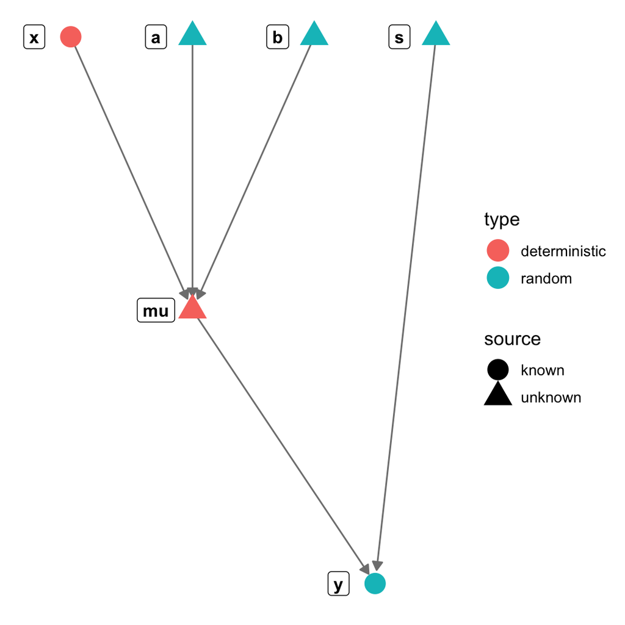

# Why Stan?

- For many models, faster than other MCMC samplers
- Fast convergence
- Very concise and natural model specification

```r
log_posterior = function(params, data) {
   a = params['a']
   B = params[grep('B', names(params))]
   s = params['s']
   y = data[['y']]
   X = data[['X']]
   if(s <= 0)
      return(-Inf)
   sum(dnorm(y, a + X %*% B, s, log = TRUE)) +
      dnorm(a, 0, 10, log=TRUE) +
      sum(dnorm(B, 0, 5, log=TRUE)) +
      dexp(s, 0.1, log=TRUE)
}
fit = optim(c(a=0,B1=0, B2=0, s = 1), log_posterior, data = data, control=list(fnscale=-1), hessian=TRUE)
vcv = solve(-fit$hessian)
samples = mvtnorm::rmvnorm(5000, fit$par, vcv)
```

```stan
data {
   int n;
   int k;
   vector [n] y;
   matrix [n,k] X;
}
parameters {
   real a;
   vector [k] B;
   real <lower=0> s;
}
model {
   y ~ normal(a + X * B, s);
   a ~ normal(0, 10);
   B ~ normal(0, 5);
   s ~ exponential(0.1);
}
```

```r
library(rstan)
standata = list(
    y = y,
    X = as.matrix(X),
    n = nrow(X),
    k = ncol(X)
)
fit = stan(stancode, iter=5000, data = standata)
samples = as.matrix(fit)
```

# Variables in Stan

- Stan variables are less flexible than in R (*strongly-typed*)
- Variables must be declared, types are fixed
- Vector/matrix/array dimensions must be specified ahead of time
- Variables must be declared in particular places
- Variables can have **constraints**

**Scalar types**

- `int`
- `real`

**Containers**

- `vector`: 1 dimension, real numbers only
- `matrix`: 2 dimensions, real numbers only
- `array`: any dimensions, any data type (including other containers!)

```stan
int my_int;
real my_real;
real <lower=0> my_positive_real;
real <lower=0, upper=1> my_proportion;

vector [10] my_ten_reals;
matrix [n,k] my_matrix;
vector <lower=0> [n] n_positive_numbers;

int ten_integers [10]; // array of ints
real ten_reals [10]; // array of reals
vector <lower=0> [10] array_of_vectors [5]; // 5 vectors, each of length 10
```

# Program blocks

- A Stan program is divided into blocks
- Blocks *must* be specified in the order here
- Required blocks for a useful model are `data`, `parameters`, and `model`

```stan
functions {
   // for user-defined functions;
   // see the manual for how to format these
}
data {
   // declare all the data you will pass to Stan
}
transformed data {
   // In this block, you can code any transformations to
   //     your data that you want to do within Stan
}
parameters {
   // declare the names and dimensions of all parameters
   //     in your model
   // a parameter is normally any stochastic-unknown on
   //     your model graph
}
transformed parameters {
   // transformations for your parameters go here
   // in many cases, these will be for
   //    deterministic-unknowns
}
model {
   // probability statements, including
   //    likelihood and priors
}
generated quantities {
   // optional, used e.g., for posterior
   //    predictive simulations
}
```

# Scope

- All variables have a scope (where the variable is visible)
- Variables declared at the top of a block are visible in that block, and all blocks below

```stan
data {
   // declare all the data you will pass to Stan
}
transformed data {
   print(param1); // ERROR!
}
parameters {
   real param1;
}
model {
   print(param1); // ok!
}
```

# Scope

- All variables have a scope (where the variable is visible)
- Variables declared at the top of a block are visible in that block, and all blocks below
- Variables declared later in a block must come at the beginning of a block denoted by {}
- These variables are only visible within that block

```stan
transformed data {
   vector[n] x;
   for(i in 1:n) {
      real x2 = 0;
      x2 = x2 + x[i]^2
      print(x2); //ok !
   }
   print(x2); // error!
}
```

# Probability statements

- In the `model` block, we write statements describing how to evaluate the log probability of the model.
- This works using the `~` symbol
- Here, the model evaluates $pr(y | \mu, \sigma)$ using the **normal PDF**
- This quantity is then added to the total log probability of the model
- This works if y is a vector or a single value

```stan
model {
   y ~ normal(mu, sigma);
}
```

# German Tank problem: Stan model

2. Recall the German tank problem presented in lecture. Use the following captured serial numbers:

```r
s = c(147, 126, 183, 88, 9, 203, 16, 10, 112, 205)
```

1. Write a log likelihood function that computes $\log pr(s | N_{max})$. What distribution is appropriate? Assume that the observations in $s$ are independent and random; $s$ can be any number between 1 and $N_{max}$, and the probability of any number in that range being observed is the same as for any other number.
2. Write a log prior for $N_{max}$, and combine it with the log likelihood into a log posterior function.

$$\begin{aligned}
s & \sim \mathrm{U}(1, N_{max}) \\
N_{max} & \sim \mathrm{Gamma}(\alpha=0.001, \beta=0.001)
\end{aligned}$$

```stan
data {
   int <lower = 1> n;
   vector <lower=1> [n] s;
}
parameters {
   real <lower = max(s)> Nmax;
}
model {
   s ~ uniform(1, Nmax); // likelihood
   // this is a super vague prior!
   Nmax ~ gamma(0.001, 0.001);
}
```

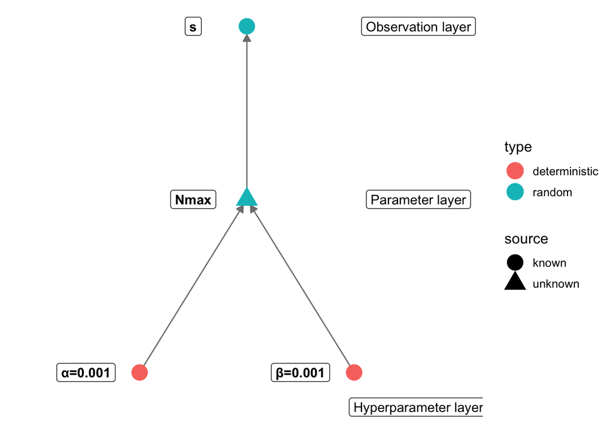

# German Tank problem: MAP estimate

3. This posterior distribution cannot be estimated using Laplace approximation. However you can still use optim to get a MAP estimate. Get the MAP estimate, then plot the log_posterior against many values of $N_{max}$. Does your MAP estiamte make sense?

```r
log_posterior = function(params, data) {
    # here we 'unpack' the objects to make the names clearer
    Nmax = params[1]
    s = data[['s']]

    # the sampler sometimes selects impossible values for Nmax
   # need to rule them out
    if(Nmax < 1) {
        return(-Inf)
    }

    log_liklihood = sum(dunif(s, 1, Nmax, log=TRUE))
   ## this is a super vague prior!
    log_prior = dgamma(Nmax, 0.001, 0.001, log = TRUE)
    # log_prior = 0
    return(log_liklihood + log_prior)
}
```

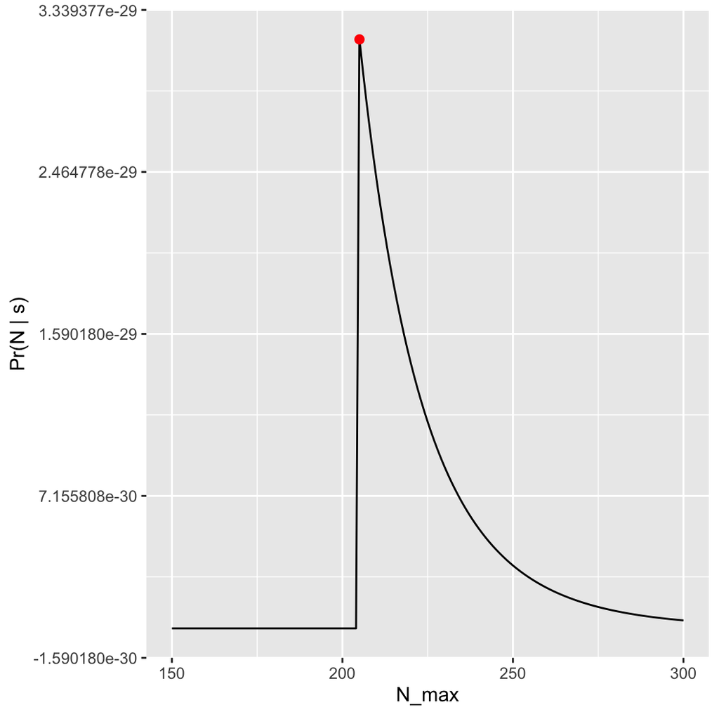

```r
library(rstan)
standat = list(n = length(s), s = s)
fit_map = optimizing(stan_tanks, data = standat)
fit_map$par
## Nmax
##  205
```

# German Tank problem: inference

```r
fit = sampling(stan_tanks, data = standat, iter=20000, chains = 1, refresh = 0)

## use if running from a separate .stan file
# fit = stan("path/to/code.stan", data = standat, iter=20000)
samples = as.matrix(fit)
head(samples)
##           parameters
## iterations     Nmax      lp__
##       [1,] 225.8251 -56.75723
##       [2,] 224.2901 -56.75694
##       [3,] 213.0184 -57.05402
##       [4,] 224.6018 -56.75656
##       [5,] 246.9740 -57.06596
##       [6,] 225.3133 -56.75655
```

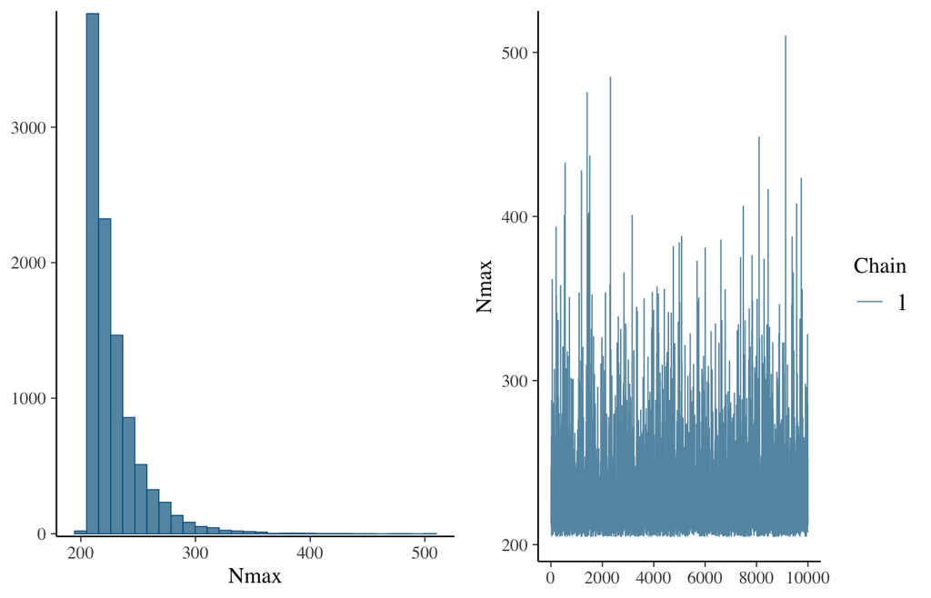

```r
source("../r/metrop.r")
library(bayesplot)
mcmc_combo(samples, c("hist", "trace"), pars = "Nmax")
```

```r
rbind(hdpi = hpdi(samples[,1]),
      quantile = quantile(samples[,1], c(0.05, 0.95)))
##                5%      95%
## hdpi     205.0067 257.1649
## quantile 206.1038 274.9726
```

# Bayesian analysis workflow

1. Specify joint posterior graphically, mathematically, and in code

# Bayesian analysis workflow

1. Specify joint posterior graphically, mathematically, and in code
2. Draw samples from the joint posterior distribution

# Bayesian analysis workflow

1. Specify joint posterior graphically, mathematically, and in code
2. Draw samples from the joint posterior distribution
3. Evaluate/diagnose the model’s performance

# Bayesian analysis workflow

1. Specify joint posterior graphically, mathematically, and in code
2. Draw samples from the joint posterior distribution
3. Evaluate/diagnose the model’s performance
4. Perform posterior inference

# 1. Joint posterior: likelihood

- Liklihood is a **generative model** (the distribution from which the observations are generated)
  - whenever possible use knowledge of the appropriate processes
  - transform parameters and sample in transformed space to improve behaviour
  - e.g. use log($\sigma$) instead of $\sigma$ to avoid impossible negative variance in sampler
  - in Stan, this is done by adding variable **constraints** (`real <lower=0> sigma`)

# 1. Joint posterior: likelihood

- Liklihood is a **generative model** (the distribution from which the observations are generated)
  - whenever possible use knowledge of the appropriate processes
  - transform parameters and sample in transformed space to improve behaviour
  - e.g. use log($/sigma$) instead of $/sigma$ to avoid impossible negative variance in sampler
  - in Stan, this is done by adding variable **constraints** (`real <lower=0> sigma`)
- Models should be specified to be scale independent
  - Easy: scaling your predictors to have mean=0, sd=1
  - Hard: scaling outcomes (y); this can change the generative model!
  - Prefer to transform outcomes with the **link function**

# 1. Joint posterior: priors

- Any unknowns must have a **prior**
  - (or possibly a hierarchical generative model and hyperpriors)
- Prefer regularising priors to vague priors
  - Normal(0, 5) instead of Normal(0,500)
- Avoid improper priors: Uniform(-Inf, Inf)
- Forget conjugacy unless you know what you are doing and why

# 1. Joint posterior: priors

- Avoid hard boundaries
  - **No**: Uniform(0, 1000)
  - **Yes**: Exponential(0.1)
- With informative priors, specify reasonable initial values
- Begin sampling with weaker priors, gradually strengthen once you know the model is working
- Specify priors for everything—avoid defaults
- Draw out your model as a digraph to make sure you don’t miss anything

# GLM in Stan

For this exercise, you will use the [birddiv](https://raw.githubusercontent.com/mtalluto/vu_advanced_statistics/main/docs/exercises/data/birddiv.csv) (in `docs/exercises/data/birddiv.csv`) dataset; you can load it directly from github using `data.table::fread()`. Bird diversity was measured in 1-km^2 plots in multiple countries of Europe, investigating the effects of habitat fragmentation and productivity on diversity. We will consider a subset of the data. Specificially, we will ask how various covariates are associated with the diversity of birds specializing on different habitat types. The data have the following potential predictors:

- **Grow.degd**: growing degree days, a proxy for how warm the climate is.
- **For.cover**: Forest cover near the sampling location
- **NDVI**: normalized difference vegetation index, a proxy for productivity
- **For.diver**: Forest diversity in the forested area nearby
- **Agr.diver**: Diversity of agricultural landscapes
- **For.fragm**: Index of forest fragmentation

All of the above variables are standardized to a 0-100 scale. Consider this when choosing priors.

Your response variable will be **richness**, the bird species richness in the plot. Additionally, you have an indicator variable **hab_type**. This is not telling you what habitat type was sampled (plots included multiple habitats). Rather, this is telling you what type of bird species were counted for the richness measurement: so `hab_type == "forest" & richness == 7` indicates that 7 forest specialists were observed in that plot.

Build one or more generalised linear models for bird richness. Your task should be to describe two things: (1) how does richness vary with climate, productivity, fragmentation, or habitat diversity, and (2) do these relationships vary depending on what habitat bird species specialize on.

# 1. Specify joint posterior

- We should specify a **generative model**
- Best to graph the model, ensure graph and stan code match
- Strive for independence of the scale of the x-variables
- Carefully choose priors
  - With no prior information, prefer **regularising priors**
  - Avoid priors that give probability mass to impossible values (e.g., normal(0,1) for a standard deviation)
  - Avoid flat priors or very long tails

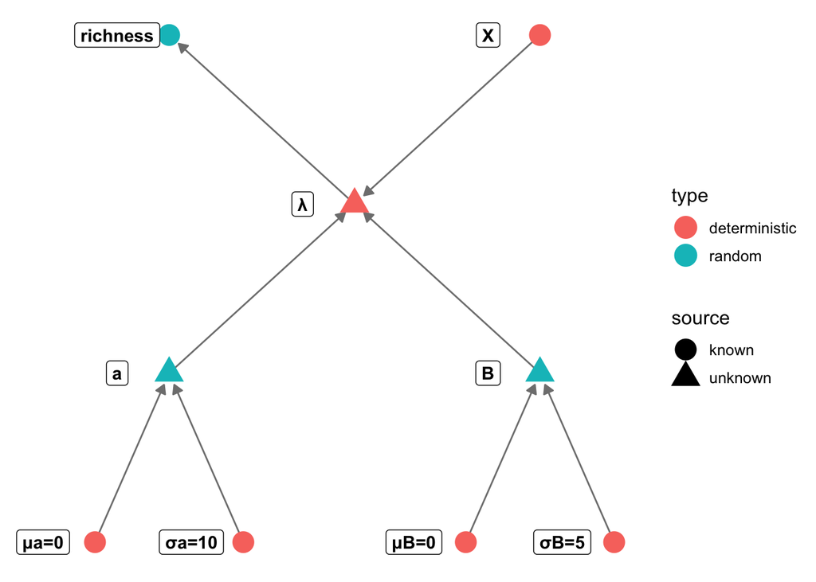

```stan
transformed parameters {
    lambda = exp(a + X * B);
}
model {
    richness ~ poisson(lambda);
    a ~ normal(0, 10);
    B ~ normal(0, 5);
}
```